# Tandis que les IA rôdent : Pratiques et expériences de création d’outils pédagogiques

Ingé-Stat Toulouse

Christophe Bontemps (SIAP)

[figure not shown]

# Disclaimer

*``The presentation of the material in this presentation do not imply the expression of any opinion whatsoever on the part of the Secretariat of the United Nations. The views expressed in this presentation are those of the author(s) and do not necessarily reflect the views or policies of the United Nations.’’*

[figure not shown]

# Désolé…

“I don’t think he speaks

English or Latin.”

## Pourquoi je créee des outils pédagogiques interactifs?

- Une majorité de cours en-ligne
- Beaucoup de participants (Massive Learning - MOOC)
- Tutoriels à faire avant les cours en présence

[figure not shown]

## Quatre exemples

Tutoriels R avec *learner*

[figure not shown]

Scrollytelling avec *R* et *closeread*

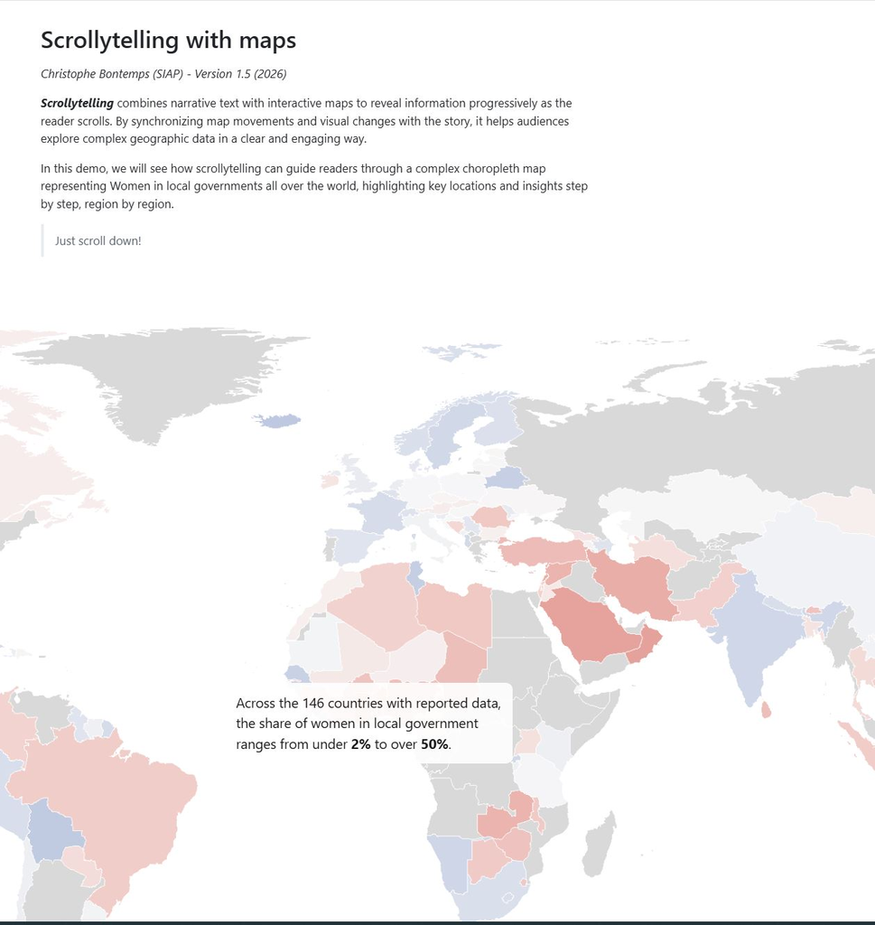

*Widgets* interactifs avec *Observable*

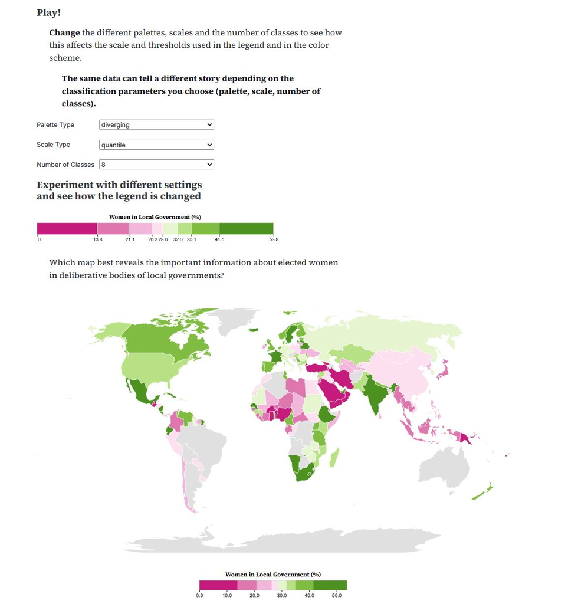

Tutoriel SQL en *Html5*

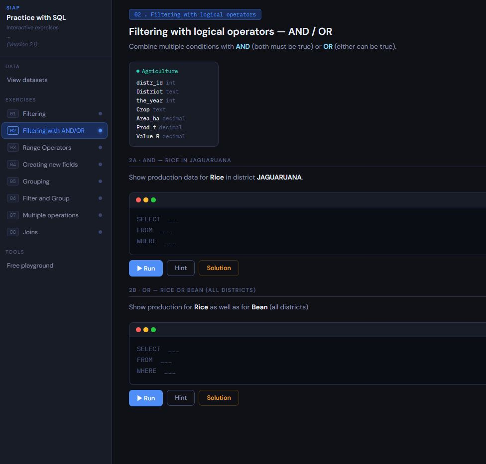

## Un par un: Le package *learner*

Tutoriels interactifs pour R :

- Exercices en R exécutables directement, sans installation
- Questions à choix multiples
- Feedback immédiat pour l’apprenant
- Intégration facile (**Shiny**)

[figure not shown]

> Creation: Moi (100%), code: Moi (95%)

## Scrollytelling avec R + Closeread

[closeread](https://closeread.dev/) est une extension de Quarto pour le *scrollytelling*

- Intégré dans RStudio/Quarto
- Quarto doc avec options YAML
- Zoom, pan, triggers, highlights
- Html hébergé sur GitHub

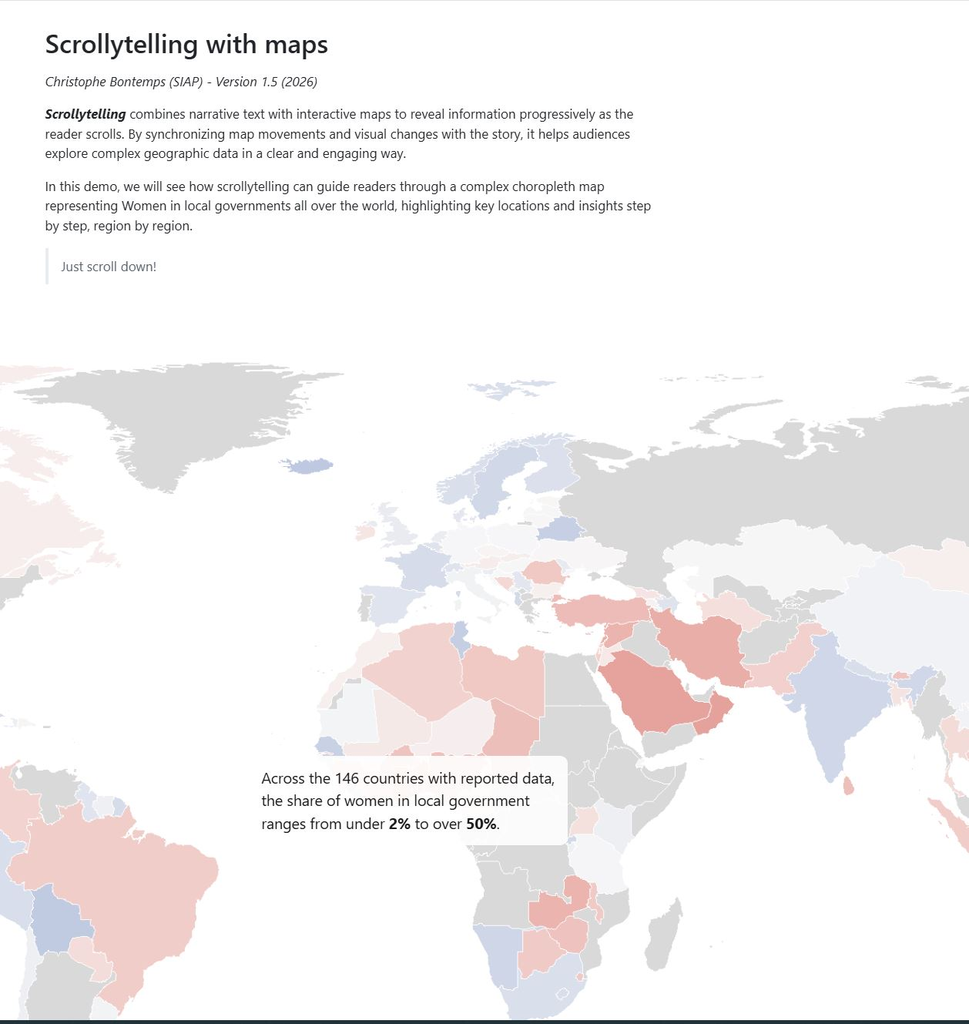

> Creation: Moi (100%), code: Moi (90%)

## Widgets avec Observable

[Obervable](https://observablehq.com/about) est une plateforme de de visualization de données

- Combine JavaScript (D3.js), Markdown (texte), Observable plot,…
- Trés ouverte
- Axée travail collaboratif
- Hébergement et partage facile

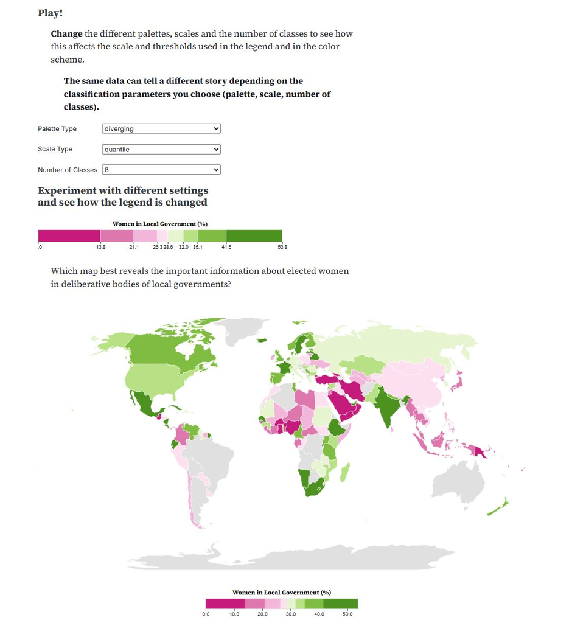

> Creation: Moi (100%). Code: Observable (60%) + AI (20%)

## Tutoriel SQL en Html5

**HTML** tout le monde connait…mais [alasSQL](https://github.com/alasql/alasql)

- SQL dans le navigateur
- Trés rapide
- CSS intégré dans le navidateur (ou ailleurs)
- Tout l’environnement html

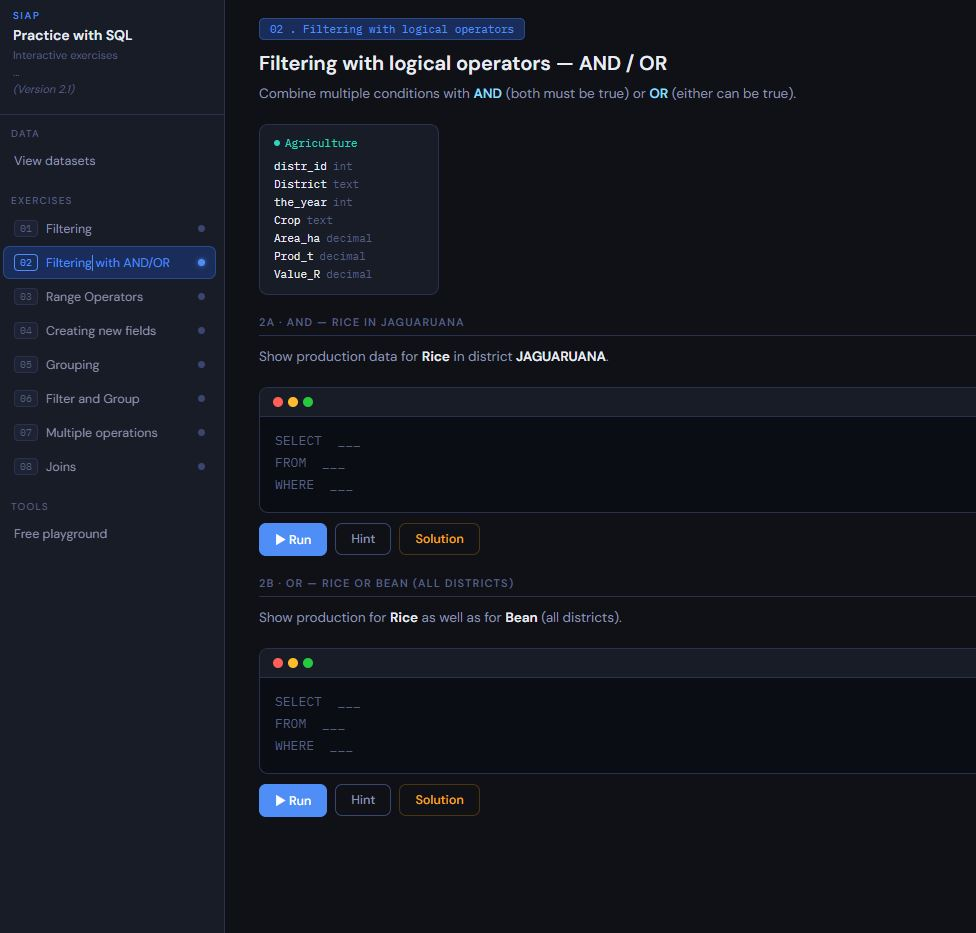

> Creation: Moi (50%). Code: **AI (90%)**

# L’histoire:

“Tout ne s’est pas déroulé

comme ça…”

## Quand on ne connaît que shiny…

Avec [RMySQL](https://cran.r-project.org/web/packages/RMySQL/index.html) et [DBI](https://dbi.r-dbi.org/) on peut émuler SQL en Shiny!

- Exercises interactifs (shiny) mais en SQL interprétés par *RmySQL*
- Bases de données reliées par *DBI* hébergées sur *freeSQL.com*
- Solution pas vraiment *scalable*

[figure not shown]

> Creation: Moi (90%). Code: Moi (50%)

## Mon IA sait des choses..

- Ma solution pas trés élégante…
- mais **code maitrisé!**
- *alasSQL* plus rapide et plus sûr.
- mais **code moins maitrisé**…

[figure not shown]

> Creation: Moi (90%). Code: Moi (50%)

# Morale…

Les IA rôdent…

… pour nous?

## Autres réalisations.

#### Surfaces are hard to evaluate

[Game on visualization](https://old.observablehq.com/embed/%40xtopheb/surfaces-are-hard-to-evaluate?cell=*) (Observable)

#### Redesign the Chart

[Inclusivity in dataviz](https://xtopheb.github.io/ADV-Course/GenderBias/InclusiveChartGame.html) (Html)

#### Beware of Maps

[Visualizing Population (migrants) on Maps](https://observablehq.com/@xtopheb/visualizing-statistics-on-maps) (Observable)

Pour plus d’info, contactez moi ou visitez mon espace [GitHub](https://github.com/XtopheB).